# Gap Credit Spread Strategy

## Phase 1 Research Summary

**Universe:** ES · NQ · RTY · YM (CME Globex, continuous futures) **Data:** 7 years · 1-minute OHLCV · 2019 – 2026 · ~10M bars (Databento) **Authored:** Hernan Rosenblum · June 2026

> *A friend made an exceptional trade: 2.5% gap-up on ES+NQ, sold a bull put spread at prior close, held to near end of day, captured ~95% of max profit.*

> **Can that be systematized?**

```
Loading data …
```

```
Data loaded.
```

## 1 · The Gap Landscape

**Definition:** An overnight gap occurs when today's open differs from yesterday's close by ≥ 1×ATR(14).

We detected gaps across all four instruments and found a striking structural fact.

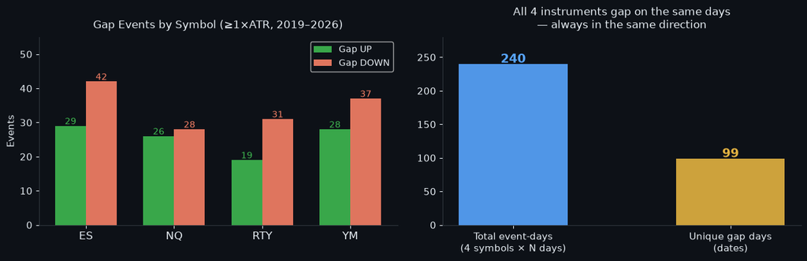

**Fear > Greed:** Gap-downs outnumber gap-ups in every symbol, consistent with volatility-asymmetry theory (fear moves faster than euphoria).

## 2 · The Core Finding: Gaps Don't Fill

If you sell an OTM option with the short strike at the **prior day's close**, how often does price close on the safe side of that strike by end of day?

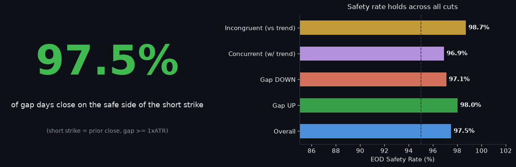

**This is the foundation of the entire strategy.**

A ≥1×ATR overnight gap almost never fully reverses within a single session. Incongruent gaps (gap against the prevailing 30-day trend — e.g., a fear spike in a bull market) are *even safer* at **98.7%**, suggesting the trend acts as an anchor pulling price back toward the gap direction.

## 3 · Trend Alignment

We classified each gap day by whether it moves *with* (concurrent) or *against* (incongruent) the 30-day price trend.

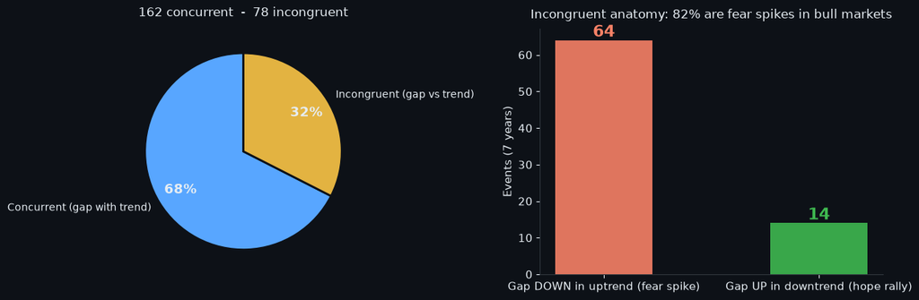

Gap-up in a downtrend is rare (14 events in 7 years): the market doesn't often produce hope rallies strong enough to gap when the trend is bearish.

## 4 · The Frequency Problem

14 unique gap days per year is not enough to build a primary strategy around. We tested ATR thresholds from 0.25× to 2.0× to find a better frequency/quality tradeoff.

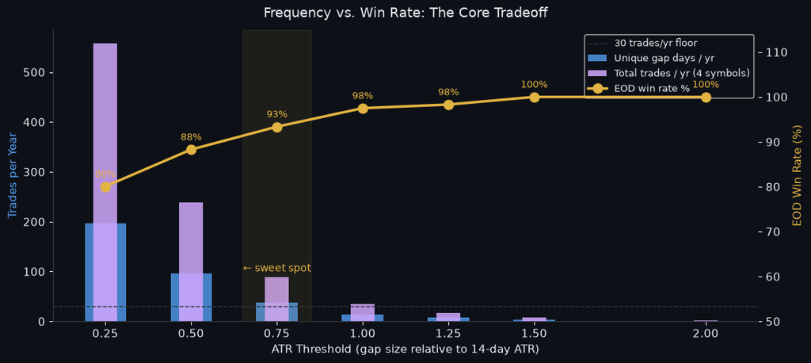

| Threshold | Unique days/yr | Total trades/yr | EOD win rate |
| --- | --- | --- | --- |
| 0.25× | 194 | 548 | 80% — too noisy |
| 0.50× | 94 | 235 | 88% |
| **0.75×** | **37** | **88** | **93%** ← recommended |
| 1.00× | 14 | 34 | 97.5% — original |
| 1.50× | 4 | 8 | 100% — too rare |

**0.75×ATR** triples the trade count while keeping win rate above 90%. The elbow in the win-rate curve sits between 0.75× and 1.00×.

## 5 · Three Strategies — What We Tested

Phase 1 explored three ways to trade gap days:

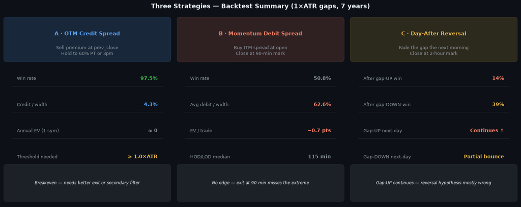

## 6 · What Phase 1 Established

### Not Found ✗

- A reliable 90-minute momentum window (Strategy B: 51% win, negative EV)
- A systematic day-after reversal edge (Strategy C: 14% win rate after gap-up)
- A clearly profitable credit spread exit rule with current parameters

### The Open Question

The **97.5% EOD safety rate is real** — the edge exists at the macro level. But the simple credit spread structure barely captures it.

> *"The gap signal is necessary but not sufficient. We need a secondary condition to know which gaps offer the most mispriced premium."*

## 7 · Phase 2 — Where We Go Next

### Hypothesis

The credit spread edge is conditional on **VIX regime**, **gap-size tier**, and **trend alignment**. Stratifying the 240 events along these three dimensions should reveal a high-conviction subset where premium is systematically mispriced.

### Planned Work

| # | Task | Signal being tested |
| --- | --- | --- |
| 2.1 | VIX regime stratification | Does high VIX → more mispriced premium? |
| 2.2 | Gap-size tiers (0.75–1.0, 1.0–1.5, 1.5+) | Larger gap → safer short strike? |
| 2.3 | Alignment × direction interaction | Incongruent fear spikes vs concurrent gaps |
| 2.4 | Exit rule optimization | EOD hold vs 50%/60%/75%/80% profit targets |
| 2.5 | Intraday entry timing | Open vs 15-min pullback vs VWAP touch |
| 2.6 | Portfolio construction | Optimal subset: which conditions to stack? |

### Success Criteria

Identify a subset of gap events (ideally 20–40/year across all symbols) where:

- Win rate ≥ 95%
- Credit/width ≥ 15%
- EV/trade clearly positive after realistic slippage

*Phase 1 complete. 7 years of data. 3 strategies tested. Foundation established.*